# Estudis d'Informàtica, Multimedia i Telecomunicacions

## 2.2 Visualització

La visualització de les dades és una eina molt valuosa, ja que ens pot permetre entendre relacions que no haviem vist fins ara, aportant un coneixement major sobre les dades que tenim.

```r
library(ggplot2)
library(gridExtra)
library(rlang)
```

En funció del tipus de variable amb el que treballarem optarem per un tipus de visualització o una altre. Per a simplificar el codi, crearem una funció per a cada tipus de variables i les separarem en grups. Com hi ha 21 variables, visualitzarem aquelles dades que poden ser més interessants.

- *credit_history*: Reflecteix el comportament de pagament passat, que pot ser un bon predictiu del comportament futur.
- *amount*: Indica la càrrega financera del préstec i influïr directament en la capacitat de pagament.
- *employment_length*: Reflecteix la seguretat laboral, que està directament relacionada amb la capacitat del client per a mantenir ingressos estables.
- *savings_balance*: Mostra la capacitat del client per estalviar. A més, pot ser un coixí contra el deute.
- *age*: Pot estar relacionada amb la maduresa financera i la fase de vida del client respecte als ingressos i despeses.
- *residence_history*: Mostra l’estabilitat domèstica.

Aquestes variables han estat seleccionades perquè juntes proporcionen una visió àmplia de la salut financera i l’estabilitat dels clients dels préstecs. Per poder fer les visualitzacions de les variables numèriques primer les tornarem a transformar a valor numèrics.

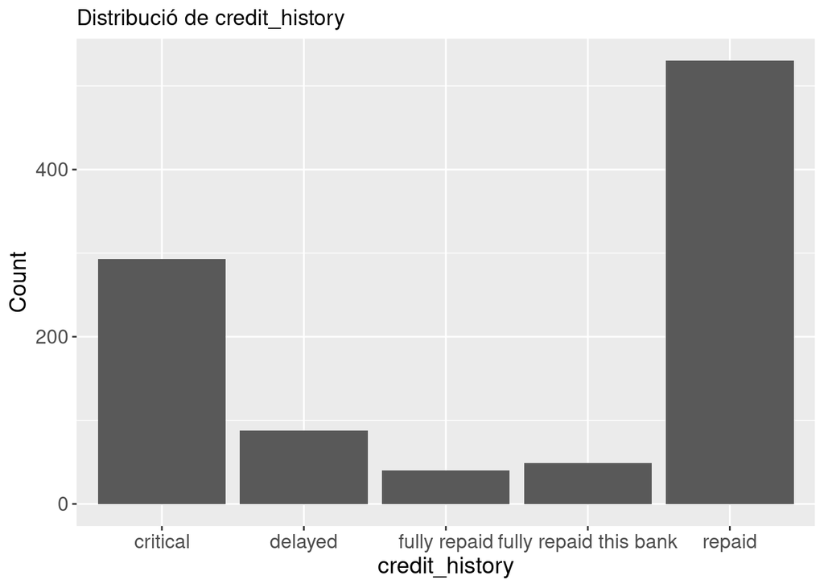

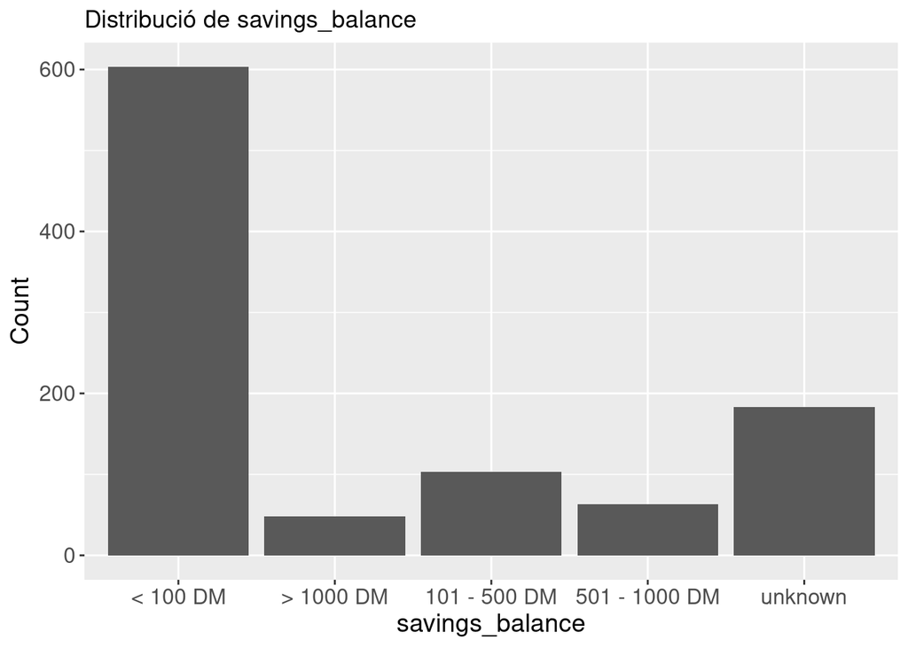

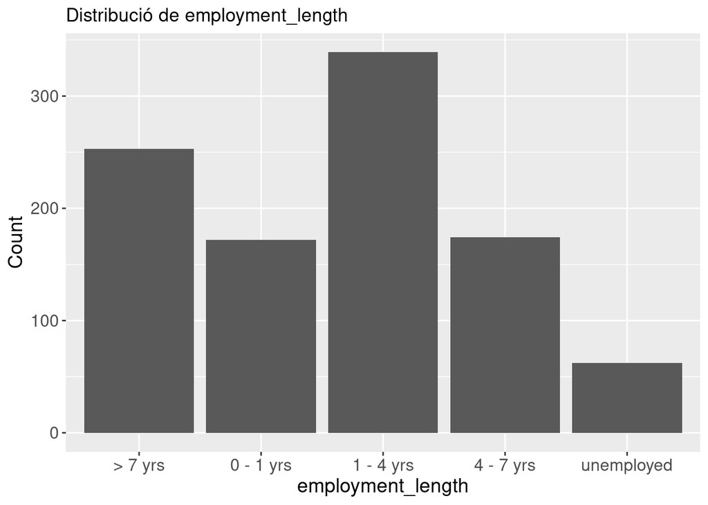

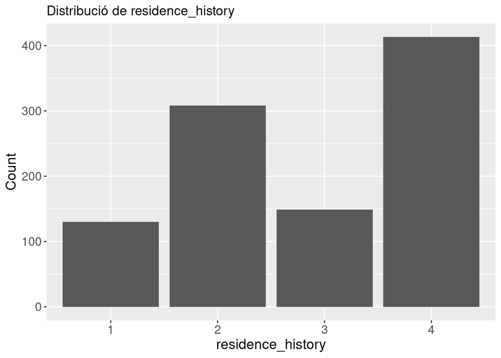

```r
data$amount <- as.numeric(as.character(data$amount))
data$age <- as.numeric(as.character(data$age))

# Separació en diferents grups
grafics_barres_vars <- c("credit_history", "savings_balance", "employment_length", "residence_history")
histogrames_vars <- c("amount", "age")

# Crear i mostrar gràfics de barres
for (var in grafics_barres_vars) {
  print(
    ggplot(data, aes_string(x = var)) +
      geom_bar() +
      labs(title = paste("Distribució de", var), x = var, y = "Count") +
      theme(axis.text = element_text(size = 12),  # Mida de l'etiqueta dels tics dels eixos
            axis.title = element_text(size = 14))  # Mida del títol dels eixos
  )
}
```